# # 1. Description

## 1.1 Background and Context

AllLife Bank wants to focus on its credit card customer base in the next financial year. They have been advised by their marketing research team, that the penetration in the market can be improved. Based on this input, the Marketing team proposes to run personalised campaigns to target new customers as well as upsell to existing customers. Another insight from the market research was that the customers perceive the support services of the back poorly. Based on this, the Operations team wants to upgrade the service delivery model, to ensure that customers queries are resolved faster. Head of Marketing and Head of Delivery both decide to reach out to the Data Science team for help Objective: To identify different segments in the existing customer based on their spending patterns as well as past interaction with the bank.

## 1.2 Dataset: ALLLife bank

Data Description: Data is of various customers of a bank with their credit limit, the total number of credit cards the customer has, and different channels through which customer has contacted the bank for any queries, different channels include visiting the bank, online and through a call centre.

Apply the concepts and techniques you have learned in the previous weeks and summarize your insights at the end.

## 1.3 Key Questions:

Perform EDA. Apply Clustering Algorithms and mentions how many clusters are formed ? How are these segments different from each other? What are your recommendations to the bank on how to better market to and service these customers?

# 2. Data Import & Analysis

## 2.1 Import libraries

```python
import pandas as pd
import numpy as np

import matplotlib.pylab as plt
%matplotlib inline

import seaborn as sns
from sklearn.model_selection  import train_test_split
from sklearn.cluster import KMeans

from scipy.stats import zscore

# to scale the data using z-score
from sklearn.preprocessing import StandardScaler

# to compute distances
from scipy.spatial.distance import cdist

# to perform k-means clustering and compute silhouette scores
from sklearn.cluster import KMeans
from sklearn.metrics import silhouette_score

# to visualize the elbow curve and silhouette scores
from yellowbrick.cluster import KElbowVisualizer, SilhouetteVisualizer

# to perform hierarchical clustering, compute cophenetic correlation, and create dendrograms
from sklearn.cluster import AgglomerativeClustering
from scipy.cluster.hierarchy import dendrogram, linkage, cophenet

# to perform PCA
from sklearn.decomposition import PCA

# to compute distances
from scipy.spatial.distance import pdist
```

## 2.2 Read Data

```python
# Read data and store in a dataframe
credit_df = pd.read_excel("Credit Card Customer Data.xlsx")
```

## 2.3 View the first and last 5 rows of the dataset.

```python
credit_df.head()
```

|  | Sl_No | Customer Key | Avg_Credit_Limit | Total_Credit_Cards | Total_visits_bank | Total_visits_online | Total_calls_made |
| --- | --- | --- | --- | --- | --- | --- | --- |
| 0 | 1 | 87073 | 100000 | 2 | 1 | 1 | 0 |
| 1 | 2 | 38414 | 50000 | 3 | 0 | 10 | 9 |
| 2 | 3 | 17341 | 50000 | 7 | 1 | 3 | 4 |
| 3 | 4 | 40496 | 30000 | 5 | 1 | 1 | 4 |
| 4 | 5 | 47437 | 100000 | 6 | 0 | 12 | 3 |

```python
credit_df.tail()
```

|  | Sl_No | Customer Key | Avg_Credit_Limit | Total_Credit_Cards | Total_visits_bank | Total_visits_online | Total_calls_made |
| --- | --- | --- | --- | --- | --- | --- | --- |
| 655 | 656 | 51108 | 99000 | 10 | 1 | 10 | 0 |
| 656 | 657 | 60732 | 84000 | 10 | 1 | 13 | 2 |
| 657 | 658 | 53834 | 145000 | 8 | 1 | 9 | 1 |
| 658 | 659 | 80655 | 172000 | 10 | 1 | 15 | 0 |
| 659 | 660 | 80150 | 167000 | 9 | 0 | 12 | 2 |

## 2.4 Understand shape of the data

```python
credit_df.info()
```

```
<class 'pandas.core.frame.DataFrame'>
RangeIndex: 660 entries, 0 to 659
Data columns (total 7 columns):
 #   Column               Non-Null Count  Dtype
---  ------               --------------  -----
 0   Sl_No                660 non-null    int64
 1   Customer Key         660 non-null    int64
 2   Avg_Credit_Limit     660 non-null    int64
 3   Total_Credit_Cards   660 non-null    int64
 4   Total_visits_bank    660 non-null    int64
 5   Total_visits_online  660 non-null    int64
 6   Total_calls_made     660 non-null    int64
dtypes: int64(7)
memory usage: 36.2 KB
```

### Observations

1. All data types are integer.
2. There are no categorical variables to transform

```python
credit_df.describe()
```

|  | Sl_No | Customer Key | Avg_Credit_Limit | Total_Credit_Cards | Total_visits_bank | Total_visits_online | Total_calls_made |
| --- | --- | --- | --- | --- | --- | --- | --- |
| count | 660.000000 | 660.000000 | 660.000000 | 660.000000 | 660.000000 | 660.000000 | 660.000000 |
| mean | 330.500000 | 55141.443939 | 34574.242424 | 4.706061 | 2.403030 | 2.606061 | 3.583333 |
| std | 190.669872 | 25627.772200 | 37625.487804 | 2.167835 | 1.631813 | 2.935724 | 2.865317 |
| min | 1.000000 | 11265.000000 | 3000.000000 | 1.000000 | 0.000000 | 0.000000 | 0.000000 |
| 25% | 165.750000 | 33825.250000 | 10000.000000 | 3.000000 | 1.000000 | 1.000000 | 1.000000 |
| 50% | 330.500000 | 53874.500000 | 18000.000000 | 5.000000 | 2.000000 | 2.000000 | 3.000000 |
| 75% | 495.250000 | 77202.500000 | 48000.000000 | 6.000000 | 4.000000 | 4.000000 | 5.000000 |
| max | 660.000000 | 99843.000000 | 200000.000000 | 10.000000 | 5.000000 | 15.000000 | 10.000000 |

```python
# checking for missing values
credit_df.isna().sum()
```

```
Sl_No                  0
Customer Key           0
Avg_Credit_Limit       0
Total_Credit_Cards     0
Total_visits_bank      0
Total_visits_online    0
Total_calls_made       0
dtype: int64
```

### Observations

1. There are no missing values in our data
2. Sl No and Cusoemr ID are not valuable and can be dropped
3. The variance in Average Credit Limit is very high and is almost equal to the mean/average

```python
# Dropping SL_No and Customer Key as they dont add any value
credit_df.drop("Sl_No", axis=1, inplace=True)
credit_df.drop("Customer Key", axis=1, inplace=True)

# Make an additional copy of the dataframe for Hierarchical clustering techniques
h_cluster_df = credit_df.copy()
```

# 3.1 EDA

## 3.1.1 Univariate Analysis

```python
# function to plot a boxplot and a histogram along the same scale.


def histogram_boxplot(data, feature, figsize=(12, 7), kde=False, bins=None):
    """
    Boxplot and histogram combined

    data: dataframe
    feature: dataframe column
    figsize: size of figure (default (12,7))
    kde: whether to the show density curve (default False)
    bins: number of bins for histogram (default None)
    """
    f2, (ax_box2, ax_hist2) = plt.subplots(
        nrows=2,  # Number of rows of the subplot grid= 2
        sharex=True,  # x-axis will be shared among all subplots
        gridspec_kw={"height_ratios": (0.25, 0.75)},
        figsize=figsize,
    )  # creating the 2 subplots
    sns.boxplot(
        data=data, x=feature, ax=ax_box2, showmeans=True, color="violet"
    )  # boxplot will be created and a star will indicate the mean value of the column
    sns.histplot(
        data=data, x=feature, kde=kde, ax=ax_hist2, bins=bins, palette="winter"
    ) if bins else sns.histplot(
        data=data, x=feature, kde=kde, ax=ax_hist2
    )  # For histogram
    ax_hist2.axvline(
        data[feature].mean(), color="green", linestyle="--"
    )  # Add mean to the histogram
    ax_hist2.axvline(
        data[feature].median(), color="black", linestyle="-"
    )  # Add median to the histogram
```

```python
# function to create labeled barplots


def labeled_barplot(data, feature, perc=False, n=None):
    """
    Barplot with percentage at the top

    data: dataframe
    feature: dataframe column
    perc: whether to display percentages instead of count (default is False)
    n: displays the top n category levels (default is None, i.e., display all levels)
    """

    total = len(data[feature])  # length of the column
    count = data[feature].nunique()
    if n is None:
        plt.figure(figsize=(count + 1, 5))
    else:
        plt.figure(figsize=(n + 1, 5))

    plt.xticks(rotation=90, fontsize=15)
    ax = sns.countplot(
        data=data,
        x=feature,
        palette="Paired",
        order=data[feature].value_counts().index[:n].sort_values(),
    )

    for p in ax.patches:
        if perc == True:
            label = "{:.1f}%".format(
                100 * p.get_height() / total
            )  # percentage of each class of the category
        else:
            label = p.get_height()  # count of each level of the category

        x = p.get_x() + p.get_width() / 2  # width of the plot
        y = p.get_height()  # height of the plot

        ax.annotate(
            label,
            (x, y),
            ha="center",
            va="center",
            size=12,
            xytext=(0, 5),
            textcoords="offset points",
        )  # annotate the percentage

    plt.show()  # show the plot
```

```python
# Define numerical columns
num_col = ['Avg_Credit_Limit', 'Total_Credit_Cards', 'Total_visits_bank', 'Total_visits_online',
 'Total_calls_made']
num_col
```

```
['Avg_Credit_Limit',
 'Total_Credit_Cards',
 'Total_visits_bank',
 'Total_visits_online',
 'Total_calls_made']
```

## 3.1.2 Plot of Avg_Credit_Limit

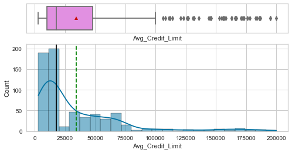

```python
histogram_boxplot(credit_df, "Avg_Credit_Limit", kde=True, figsize=(8, 4))
```

[figure not shown]

```python
labeled_barplot(credit_df, "Avg_Credit_Limit", perc=True)
```

## 3.1.3 Plot of Total_Credit_Cards

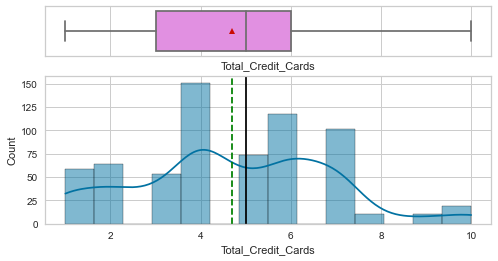

```python
histogram_boxplot(credit_df, "Total_Credit_Cards", kde=True, figsize=(8, 4))
```

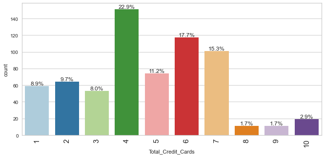

```python
labeled_barplot(credit_df, "Total_Credit_Cards", perc=True)
```

### Observations

1. Total credit cards seems to be approximately normally distributed
2. There are no outliers
3. Majority of customers have 4 cards, followed by 6 and 7.

## 3.1.4 Plot of Total_visits_bank

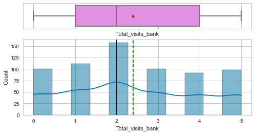

```python
histogram_boxplot(credit_df, "Total_visits_bank", kde=True, figsize=(8, 4))
```

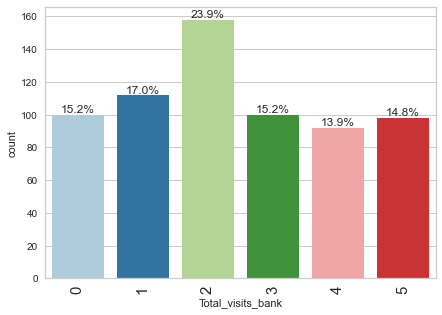

```python
labeled_barplot(credit_df, "Total_visits_bank", perc=True)
```

### Observations

1. Total_visits_bank seems to be approximately normally distributed
2. There are no outliers
3. Majority of customers have made 2 visits to the bank. The distribution for other number of visits is about the same

## 3.1.5 Plot of Total_visits_online

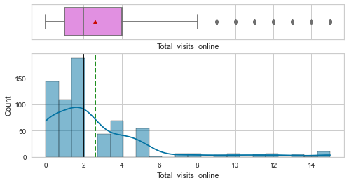

```python
histogram_boxplot(credit_df, "Total_visits_online", kde=True, figsize=(8, 4))
```

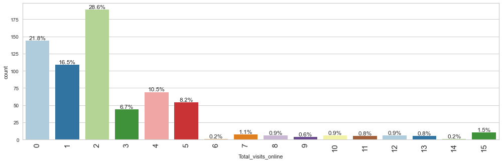

```python
labeled_barplot(credit_df, "Total_visits_online", perc=True)
```

## 3.1.6 Plot of Total_calls_made

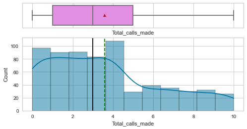

```python
histogram_boxplot(credit_df, "Total_calls_made", kde=True, figsize=(8, 4))
```

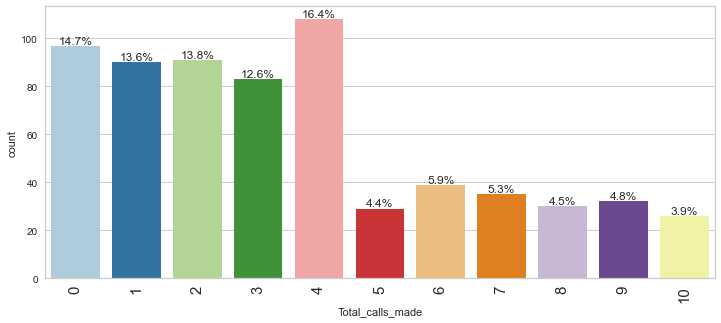

```python
labeled_barplot(credit_df, "Total_calls_made", perc=True)
```

### Observations

1. Total_calls_made seems to be a left shifted distribution
2. There are quite no outliers
3. Majority of customers have called 4 times. The distribution oif 0,1,2,3 and approximately equal.
4. Similarly the distribution of 5-10 are equal also

## 3.1.2 Bivariate Analsysis

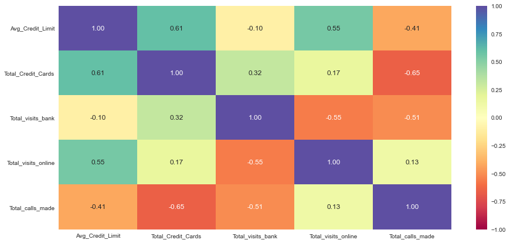

```python
plt.figure(figsize=(15, 7))
sns.heatmap(credit_df[num_col].corr(), annot=True, vmin=-1, vmax=1, fmt=".2f", cmap="Spectral")
plt.show()
```

### Observations

1. Avg Credit limit and total credit cards seem to be fairly correlated
2. total credit cards is correlated to total calls made
3. total credit cards is also correlated to total visits made to bank

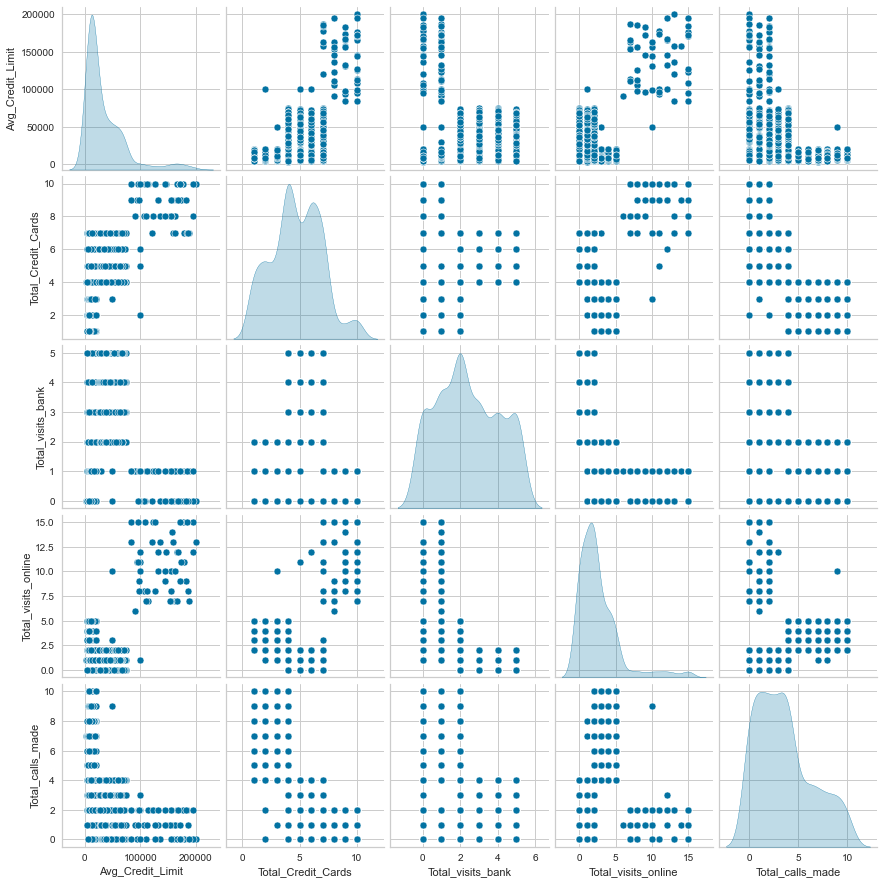

```python
sns.pairplot(data=credit_df[num_col], diag_kind="kde")
plt.show()
```

### Observations

1. There are two lumps in Total credit cards - possibly alluding to the needs for atteast two clusters
2. There are three lumps in Total visits cards - possibly alluding to the need for atteast three clusters
3. There are two lumps in Total calls made - possibly alluding to the needs for atteast two clusters

## 3.1.3 Data cleaning

```python
# Helper function to treat outliers
# Lets treat outliers by flooring and capping

def treat_outliers(df,col):
    '''
    treats outliers in a varaible
    col: str, name of the numerical varaible
    df: data frame
    col: name of the column
    '''
    Q1=df[col].quantile(0.25) # 25th quantile
    Q3=df[col].quantile(0.75)  # 75th quantile
    IQR=Q3-Q1
    Lower_Whisker = Q1 - 1.5*IQR
    Upper_Whisker = Q3 + 1.5*IQR
    df[col] = np.clip(df[col], Lower_Whisker, Upper_Whisker) # all the values samller than Lower_Whisker will be assigned value of Lower_whisker
                                                            # and all the values above upper_whishker will be assigned value of upper_Whisker
    return df

def treat_outliers_all(df, col_list):
    '''
    treat outlier in all numerical varaibles
    col_list: list of numerical varaibles
    df: data frame
    '''
    for c in col_list:
        df = treat_outliers(df,c)

    return df
```

```python
#Form a list of columns that have outliers and need to be treated

outlier_cols = ['Avg_Credit_Limit','Total_visits_online']

credit_df = treat_outliers_all(credit_df, outlier_cols)
h_cluster_df = treat_outliers_all(credit_df, outlier_cols)
```

# 4 Model building (Kmeans clustering)

## 4.1 Scale data

```python
# Scaling the data set before clustering
scaler = StandardScaler()
subset = credit_df[num_col].copy()
subset_scaled = scaler.fit_transform(subset)
```

```python
# Creating a dataframe from the scaled data
subset_scaled_df = pd.DataFrame(subset_scaled, columns=subset.columns)
```

## 4.2 Selecting K with Elbow method

```
Number of Clusters: 1 	Average Distortion: 2.0731463576129583
Number of Clusters: 2 	Average Distortion: 1.4986141501796377
Number of Clusters: 3 	Average Distortion: 1.1823298853410935
Number of Clusters: 4 	Average Distortion: 1.0711026440504199
Number of Clusters: 5 	Average Distortion: 1.0049111763726386
Number of Clusters: 6 	Average Distortion: 0.9519255245757801
Number of Clusters: 7 	Average Distortion: 0.9149721917550735
Number of Clusters: 8 	Average Distortion: 0.8904643763410436
```

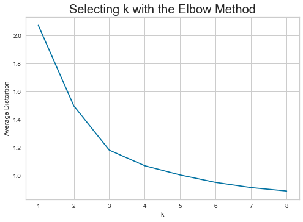

```python
clusters = range(1, 9)
meanDistortions = []

for k in clusters:
    model = KMeans(n_clusters=k)
    model.fit(subset_scaled_df)
    prediction = model.predict(subset_scaled_df)
    distortion = (
        sum(
            np.min(cdist(subset_scaled_df, model.cluster_centers_, "euclidean"), axis=1)
        )
        / subset_scaled_df.shape[0]
    )

    meanDistortions.append(distortion)

    print("Number of Clusters:", k, "\tAverage Distortion:", distortion)

plt.plot(clusters, meanDistortions, "bx-")
plt.xlabel("k")
plt.ylabel("Average Distortion")
plt.title("Selecting k with the Elbow Method", fontsize=20)
```

#### Observation:

The appropriate value of k from the elbow curve seems to be 2 or 3. Let's check the silhoutte scores

```
For n_clusters = 2, silhouette score is 0.4201583924929177
For n_clusters = 3, silhouette score is 0.5169867470092899
For n_clusters = 4, silhouette score is 0.38147048130671246
For n_clusters = 5, silhouette score is 0.35332888701008774
For n_clusters = 6, silhouette score is 0.271387209779717
For n_clusters = 7, silhouette score is 0.2668200043869383
For n_clusters = 8, silhouette score is 0.2582687424515485
For n_clusters = 9, silhouette score is 0.24315877334555586
```

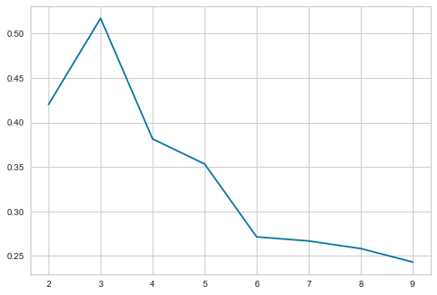

```python
sil_score = []
cluster_list = list(range(2, 10))
for n_clusters in cluster_list:
    clusterer = KMeans(n_clusters=n_clusters)
    preds = clusterer.fit_predict((subset_scaled_df))
    # centers = clusterer.cluster_centers_
    score = silhouette_score(subset_scaled_df, preds)
    sil_score.append(score)
    print("For n_clusters = {}, silhouette score is {}".format(n_clusters, score))

plt.plot(cluster_list, sil_score)
```

#### Observations:

From the silhoutte score it seems like 3 is a good value of k

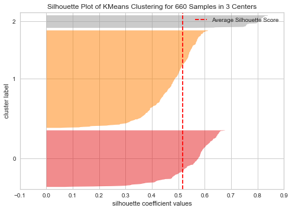

```python
# finding optimal no. of clusters with silhouette coefficients
visualizer = SilhouetteVisualizer(KMeans(3, random_state=1))
visualizer.fit(subset_scaled_df)
visualizer.show()
```

```python
kmeans = KMeans(n_clusters=3, random_state=0)
kmeans.fit(subset_scaled_df)
```

```
KMeans(n_clusters=3, random_state=0)
```

```python
# adding kmeans cluster labels to the original dataframe
credit_df["K_means_segments"] = kmeans.labels_
```

```python
cluster_profile = credit_df.groupby("K_means_segments").mean()
```

```python
cluster_profile["count_in_each_segment"] = (
    credit_df.groupby("K_means_segments")["Avg_Credit_Limit"].count().values
)
```

```python
# let's display cluster profiles
cluster_profile.style.highlight_max(color="lightgreen", axis=0)
```

| K_means_segments | Avg_Credit_Limit | Total_Credit_Cards | Total_visits_bank | Total_visits_online | Total_calls_made | count_in_each_segment |
| --- | --- | --- | --- | --- | --- | --- |
| 0 | 33782.383420 | 5.515544 | 3.489637 | 0.981865 | 2.000000 | 386 |
| 1 | 12174.107143 | 2.410714 | 0.933036 | 3.546875 | 6.870536 | 224 |
| 2 | 102660.000000 | 8.740000 | 0.600000 | 8.180000 | 1.080000 | 50 |

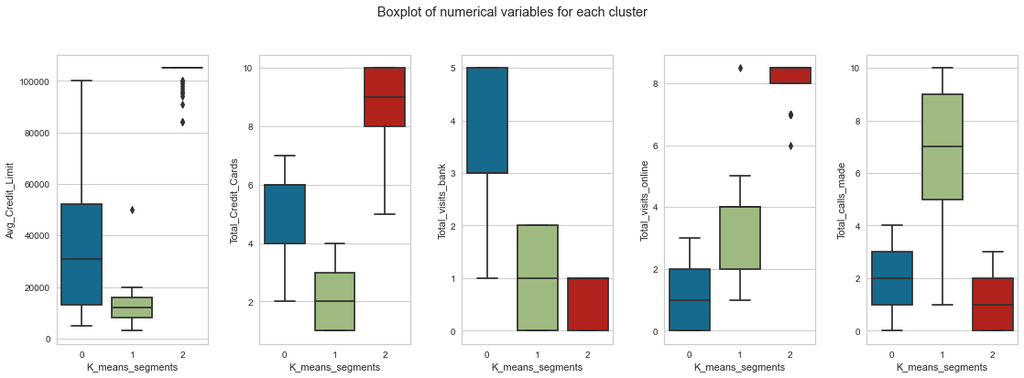

```python
fig, axes = plt.subplots(1, 5, figsize=(16, 6))
fig.suptitle("Boxplot of numerical variables for each cluster")
counter = 0
for ii in range(5):
    sns.boxplot(ax=axes[ii], y=credit_df[num_col[counter]], x=credit_df["K_means_segments"])
    counter = counter + 1

fig.tight_layout(pad=2.0)
```

```python
credit_df.groupby("K_means_segments").mean()
```

| K_means_segments | Avg_Credit_Limit | Total_Credit_Cards | Total_visits_bank | Total_visits_online | Total_calls_made |
| --- | --- | --- | --- | --- | --- |
| 0 | 33782.383420 | 5.515544 | 3.489637 | 0.981865 | 2.000000 |
| 1 | 12174.107143 | 2.410714 | 0.933036 | 3.546875 | 6.870536 |
| 2 | 102660.000000 | 8.740000 | 0.600000 | 8.180000 | 1.080000 |

## 4.3 Insights

### Cluster 0

1. Average credit line is about 33782
2. Total credit cards is in the middle - about 5.5
3. It has the highest visit to the bankand the lowest visits online

### Business Recommendations

1. The bank should focus on Cluster 0 and 1 to improve service delivery
2. The bank should focus on cluster 2 to run targeted marketing campaigns as this is the group that seems to be the happiest

# 5 Hierarchical clustering

```python
# Scaling the data set before clustering
h_scaler = StandardScaler()
h_subset = h_cluster_df[num_col].copy()
h_subset_scaled = scaler.fit_transform(h_subset)
h_subset_scaled_df = pd.DataFrame(h_subset_scaled, columns=subset.columns)
```

```python
# list of distance metrics
distance_metrics = ["euclidean", "chebyshev", "mahalanobis", "cityblock"]

# list of linkage methods
linkage_methods = ["single", "complete", "average", "weighted"]

high_cophenet_corr = 0
high_dm_lm = [0, 0]

for dm in distance_metrics:
    for lm in linkage_methods:
        Z = linkage(h_subset_scaled_df, metric=dm, method=lm)
        c, coph_dists = cophenet(Z, pdist(h_subset_scaled_df))
        print(
            "Cophenetic correlation for {} distance and {} linkage is {}.".format(
                dm.capitalize(), lm, c
            )
        )
        if high_cophenet_corr < c:
            high_cophenet_corr = c
            high_dm_lm[0] = dm
            high_dm_lm[1] = lm
```

```
Cophenetic correlation for Euclidean distance and single linkage is 0.6666982080229052.
Cophenetic correlation for Euclidean distance and complete linkage is 0.8207884321476555.
Cophenetic correlation for Euclidean distance and average linkage is 0.8926672966587861.
Cophenetic correlation for Euclidean distance and weighted linkage is 0.8872365340578665.
Cophenetic correlation for Chebyshev distance and single linkage is 0.6882876568342585.
Cophenetic correlation for Chebyshev distance and complete linkage is 0.7672199195985938.
Cophenetic correlation for Chebyshev distance and average linkage is 0.8907216945489854.
Cophenetic correlation for Chebyshev distance and weighted linkage is 0.782728724334691.
Cophenetic correlation for Mahalanobis distance and single linkage is 0.6583934280485623.
Cophenetic correlation for Mahalanobis distance and complete linkage is 0.3884943792102948.
Cophenetic correlation for Mahalanobis distance and average linkage is 0.7998609088477291.
Cophenetic correlation for Mahalanobis distance and weighted linkage is 0.622143405503045.
Cophenetic correlation for Cityblock distance and single linkage is 0.6711679581499276.
Cophenetic correlation for Cityblock distance and complete linkage is 0.8365243185904129.
Cophenetic correlation for Cityblock distance and average linkage is 0.8905302338528754.
Cophenetic correlation for Cityblock distance and weighted linkage is 0.8419484433810667.
```

```python
# printing the combination of distance metric and linkage method with the highest cophenetic correlation
print(
    "Highest cophenetic correlation is {}, which is obtained with {} distance and {} linkage.".format(
        high_cophenet_corr, high_dm_lm[0].capitalize(), high_dm_lm[1]
    )
)
```

```
Highest cophenetic correlation is 0.8926672966587861, which is obtained with Euclidean distance and average linkage.
```

#### Observation:

##### Let's explore different linkage methods with Euclidean distance only.

```python
# list of linkage methods
linkage_methods = ["single", "complete", "average", "centroid", "ward", "weighted"]

high_cophenet_corr = 0
high_dm_lm = [0, 0]

for lm in linkage_methods:
    Z = linkage(h_subset_scaled_df, metric="euclidean", method=lm)
    c, coph_dists = cophenet(Z, pdist(h_subset_scaled_df))
    print("Cophenetic correlation for {} linkage is {}.".format(lm, c))
    if high_cophenet_corr < c:
        high_cophenet_corr = c
        high_dm_lm[0] = "euclidean"
        high_dm_lm[1] = lm
```

```
Cophenetic correlation for single linkage is 0.6666982080229052.
Cophenetic correlation for complete linkage is 0.8207884321476555.
Cophenetic correlation for average linkage is 0.8926672966587861.
Cophenetic correlation for centroid linkage is 0.8880634847869346.
Cophenetic correlation for ward linkage is 0.7702265240776373.
Cophenetic correlation for weighted linkage is 0.8872365340578665.
```

```python
# printing the combination of distance metric and linkage method with the highest cophenetic correlation
print(
    "Highest cophenetic correlation is {}, which is obtained with {} linkage.".format(
        high_cophenet_corr, high_dm_lm[1]
    )
)
```

```
Highest cophenetic correlation is 0.8926672966587861, which is obtained with average linkage.
```

#### Observation:

##### 1. We see that the cophenetic correlation is maximum with Euclidean distance and average linkage.

##### 2. Let's see the dendrograms for the different linkage methods.

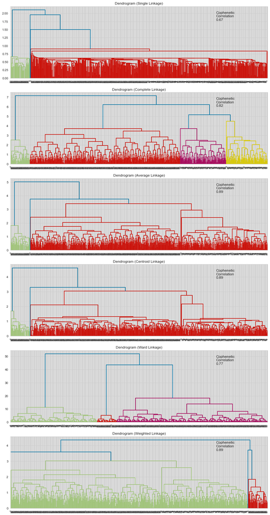

```python
# list of linkage methods
linkage_methods = ["single", "complete", "average", "centroid", "ward", "weighted"]

# lists to save results of cophenetic correlation calculation
compare_cols = ["Linkage", "Cophenetic Coefficient"]

# to create a subplot image
fig, axs = plt.subplots(len(linkage_methods), 1, figsize=(15, 30))

# We will enumerate through the list of linkage methods above
# For each linkage method, we will plot the dendrogram and calculate the cophenetic correlation
for i, method in enumerate(linkage_methods):
    Z = linkage(h_subset_scaled_df, metric="euclidean", method=method)

    dendrogram(Z, ax=axs[i])
    axs[i].set_title(f"Dendrogram ({method.capitalize()} Linkage)")

    coph_corr, coph_dist = cophenet(Z, pdist(h_subset_scaled_df))
    axs[i].annotate(
        f"Cophenetic\nCorrelation\n{coph_corr:0.2f}",
        (0.80, 0.80),
        xycoords="axes fraction",
    )
```

#### Observations

1. The Cophenetic correlation is hihest for average, centroid and weighted linkage. We will pick average therefore
2. 6 appears to be the appropriate number of clusters from the average linkage

```python
HCmodel = AgglomerativeClustering(n_clusters=6, affinity="euclidean", linkage="average")
HCmodel.fit(h_subset_scaled_df)
```

```
AgglomerativeClustering(linkage='average', n_clusters=6)
```

```python
h_subset_scaled_df["HC_Clusters"] = HCmodel.labels_
h_cluster_df["HC_Clusters"] = HCmodel.labels_
```

# 5.2 Cluster profiling

```python
h_cluster_profile = h_cluster_df.groupby("HC_Clusters").mean()
```

```python
h_cluster_profile["count_in_each_segments"] = (
    h_cluster_df.groupby("HC_Clusters")["Avg_Credit_Limit"].count().values
)
```

```python
# lets display cluster profile
h_cluster_profile.style.highlight_max(color="lightgreen", axis=0)
```

| HC_Clusters | Avg_Credit_Limit | Total_Credit_Cards | Total_visits_bank | Total_visits_online | Total_calls_made | K_means_segments | count_in_each_segments |
| --- | --- | --- | --- | --- | --- | --- | --- |
| 0 | 12027.027027 | 2.400901 | 0.932432 | 3.531532 | 6.873874 | 1.000000 | 222 |
| 1 | 33498.701299 | 5.516883 | 3.498701 | 0.979221 | 2.005195 | 0.002597 | 385 |
| 2 | 50000.000000 | 7.000000 | 1.000000 | 3.000000 | 4.000000 | 0.000000 | 1 |
| 3 | 102660.000000 | 8.740000 | 0.600000 | 8.180000 | 1.080000 | 2.000000 | 50 |
| 4 | 50000.000000 | 3.000000 | 0.000000 | 8.500000 | 9.000000 | 1.000000 | 1 |
| 5 | 100000.000000 | 2.000000 | 1.000000 | 1.000000 | 0.000000 | 0.000000 | 1 |

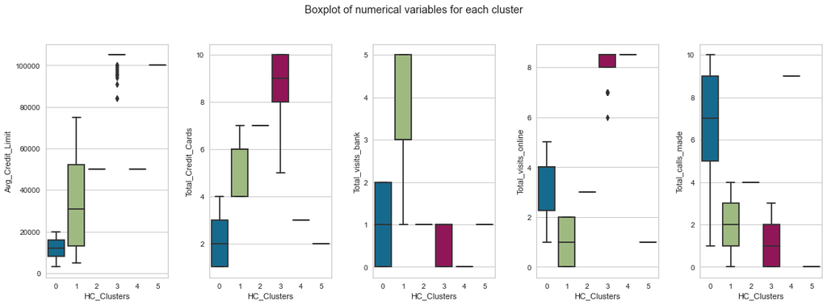

```python
fig, axes = plt.subplots(1, 5, figsize=(16, 6))
fig.suptitle("Boxplot of numerical variables for each cluster")
counter = 0
for ii in range(5):
    sns.boxplot(ax=axes[ii], y=h_cluster_df[num_col[counter]], x=h_cluster_df["HC_Clusters"])
    counter = counter + 1

fig.tight_layout(pad=2.0)
```

## 5.3 Insights

#### Cluster 2 & 4

They both have the same credit line. But group 4 makes way more calls and online visits

#### Business Recommendation

1. The marketing department should target clusters 3 &5
2. The operations team should focus on clusters 0,1, 2 & 4 to improve their operations satifcation